# Luftforurening

CMF

27 feb 2016

## Luftforurening - Københavns Kommune

Kilde: http://data.kk.dk/dataset/luftforurening

H.C. Andersens Boulevard/1103: Gadestation (12o34’20" E, 55o40’30’’ N).

Målt på gadeniveau (på stærkt trafikerede gader).

Den trafik-orienterede station (station nr. 1103) er placeret på nordsiden af en 6 sporet gade. På begge sider af hovedgaden er der parkering langs med parallelle sidegader og fortove. På Nordsiden er der 5-6 etagers beboelsesejendomme, der bl.a huser den kommunale administration, medens der på den modsatte side ligger en forlystelsespark med træer og lave bygninger. Trafiktætheden er på omkring 70.000 motorkøretøjer om dagen.

Data måles med automatiske instrumenter og opdateres hver time.

Stofliste: NO2: Kvælstofdioxid, NOx: Kvælstofoxider, CO: Kulmonoxid, O3: Ozon, PM10: Partikler mindre end 10 µm *), PM25: Partikler mindre end 2,5 µm* ), SO2: Svovldioxid, Ben: Benzen, Tol: Toluen.

Enheder: µg/m3, dog NOx: µg(NO2)/m3 og CO: mg/m3.

Data kontrolleres automatisk, men der er ikke foretaget afsluttende kontrol - der tages derfor forbehold mht. de nøjagtige værdier. Målt med: *) TEOM metoden.

Mere information kan findes hos Institut for Miljøvidenskab.

# Hent data og vis de første rækker

```r
mydata <- read.csv("~/GitHub/kk_data/Luftforurening/HC-Andersens-Boulevard.csv_rev_mod.csv")
head(mydata)
```

```
##         Dato   Tid TidsKategori NO2myg.m3 NOxmyg.NO2..m3 COmg.m3 O3myg.m3
## 1 27-02-2014 11-12           11     46.77         129.78    0.44    22.94
## 2 27-02-2014 10-11           10     45.86         143.31    0.45    18.16
## 3 27-02-2014  9-10            9     36.11          93.52    0.41    20.01
## 4 27-02-2014  8- 9            8     37.34          87.44    0.33    18.78
## 5 27-02-2014  7- 8            7     52.24         116.54    0.40     9.06
## 6 27-02-2014  6- 7            6     49.22         114.70    0.33     5.36
##   PM10.Teom.myg.m3 PM25.Teom.myg.m3 SO2myg.m3
## 1            16.45            11.25      2.10
## 2            13.80             9.70      2.74
## 3            10.90             7.15      1.43
## 4            12.05             8.35      1.29
## 5            17.60            10.70      1.75
## 6            17.80            11.60      1.76
```

Vis summary:

```r
summary(mydata)
```

```
##          Dato          Tid       TidsKategori    NO2myg.m3
##  01-02-2014: 24   0- 1   : 31   Min.   : 0.0   Min.   :  2.45
##  02-02-2014: 24   1- 2   : 31   1st Qu.: 5.0   1st Qu.: 24.75
##  03-02-2014: 24   10-11  : 31   Median :11.0   Median : 39.35
##  04-02-2014: 24   11-12  : 31   Mean   :11.4   Mean   : 41.87
##  05-02-2014: 24   2- 3   : 31   3rd Qu.:17.0   3rd Qu.: 55.69
##  06-02-2014: 24   3- 4   : 31   Max.   :23.0   Max.   :141.26
##  (Other)   :588   (Other):546
##  NOxmyg.NO2..m3      COmg.m3          O3myg.m3     PM10.Teom.myg.m3
##  Min.   :  4.83   Min.   :0.1600   Min.   : 0.23   Min.   :  0.00
##  1st Qu.: 48.77   1st Qu.:0.2600   1st Qu.:21.90   1st Qu.: 13.64
##  Median : 89.92   Median :0.3400   Median :36.05   Median : 19.52
##  Mean   :110.78   Mean   :0.3633   Mean   :36.63   Mean   : 28.14
##  3rd Qu.:141.56   3rd Qu.:0.4400   3rd Qu.:50.02   3rd Qu.: 31.95
##  Max.   :712.97   Max.   :0.9400   Max.   :79.37   Max.   :319.25
##
##  PM25.Teom.myg.m3   SO2myg.m3
##  Min.   : 0.00    Min.   :-0.040
##  1st Qu.: 6.70    1st Qu.: 0.665
##  Median : 9.05    Median : 1.420
##  Mean   : 9.61    Mean   : 1.931
##  3rd Qu.:11.30    3rd Qu.: 2.445
##  Max.   :65.25    Max.   :15.170
##
```

# Boxplot

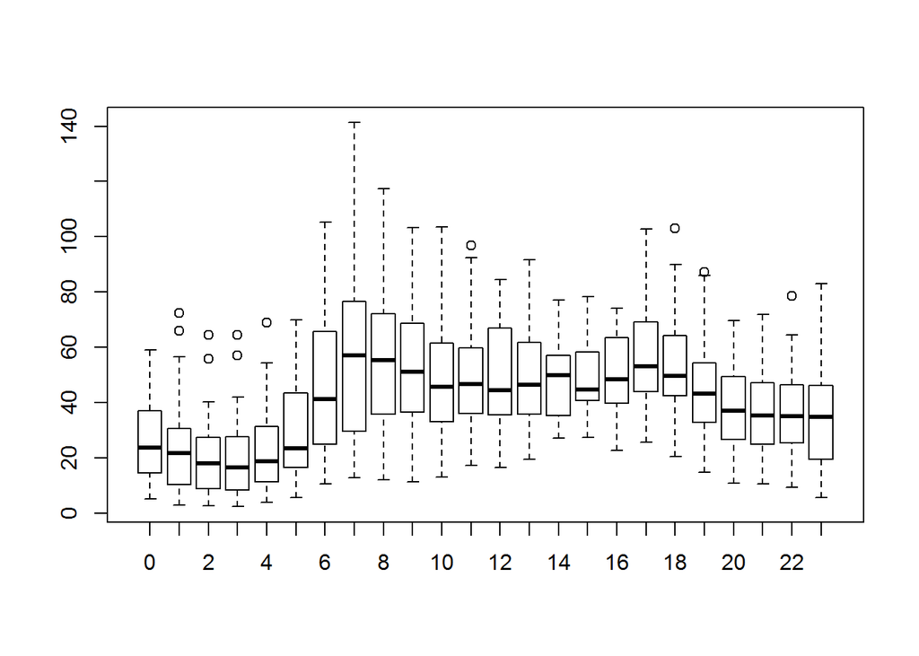

```r
boxplot(NO2myg.m3~TidsKategori,mydata)
```